# Relatório de Unidade - Autoavaliação UFRPE 2019 (UAST)

# 1 INTRODUÇÃO

Este relatório apresenta as respostas dos discentes, docentes e técnicos da Unidade Acadêmica de Serra Talhada (UAST), referente à autoavaliação 2019 da Universidade Federal Rural de Pernambuco (UFRPE), conduzida pela Comissão Própria de Avaliação (CPA). Neste ano foram contemplados dois eixos avaliativos: Planejamento e Avaliação Institucional e Desenvolvimento Institucional.

Esta avaliação foi feita a partir de questionários online, disponibilizados de forma voluntária aos discentes, docentes e técnicos da instituição, no período de 23 de abril a 29 de julho de 2019. Maiores detalhes sobre a metodologia de autoavaliação podem ser encontrados no 2º Relatório Parcial de Autoavaliação Institucional (ANO-BASE 2019), disponível no site da [CPA/UFRPE](http://cpa.ufrpe.br/br/relatorio-de-autoavaliacao-institucional/).

Note que este relatório apresenta os resultados da avaliação da UFRPE *como um todo* sob o ponto de vista dos membros desta unidade; sendo assim, não pode ser interpretado como uma avaliação da unidade propriamente dita.

# 2 PANORAMA

Dentre os membros da comunidade acadêmica desta unidade aptos a participar da avaliação, 23.4% dos estudantes responderam ao questionário (417 de 1782), 30.63% dos docentes responderam ao questionário (68 de 222), e 41.03% dos técnicos responderam ao questionário (32 de 78).

Os gráficos a seguir apresentam os resultados da avaliação de alguns itens pré-selecionados: Ações de Planejamento de Cursos e Utilização dos Resultados da Autoavaliação Institucional no Planejamento de Cursos, além da atuação da UFRPE na promoção do desenvolvimento econômico e social, da sustentabilidade, da igualdade étnico-racial, e na valorização da diversidade.

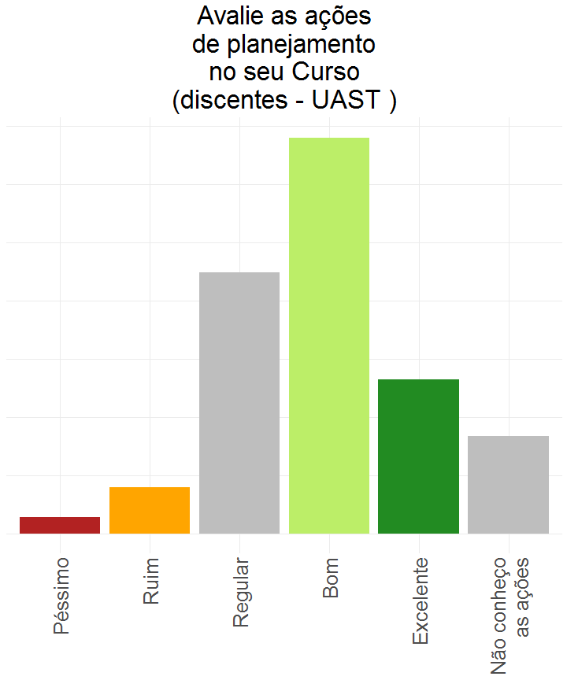

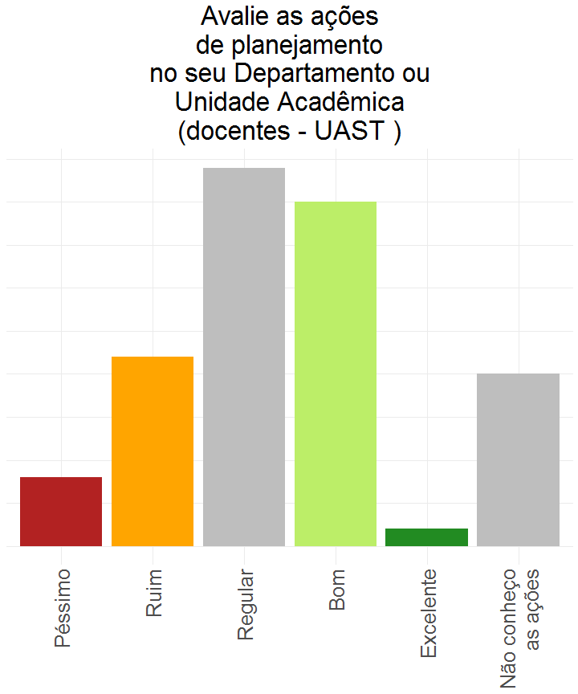

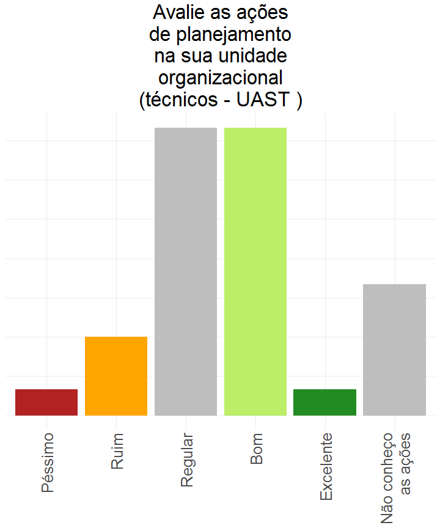

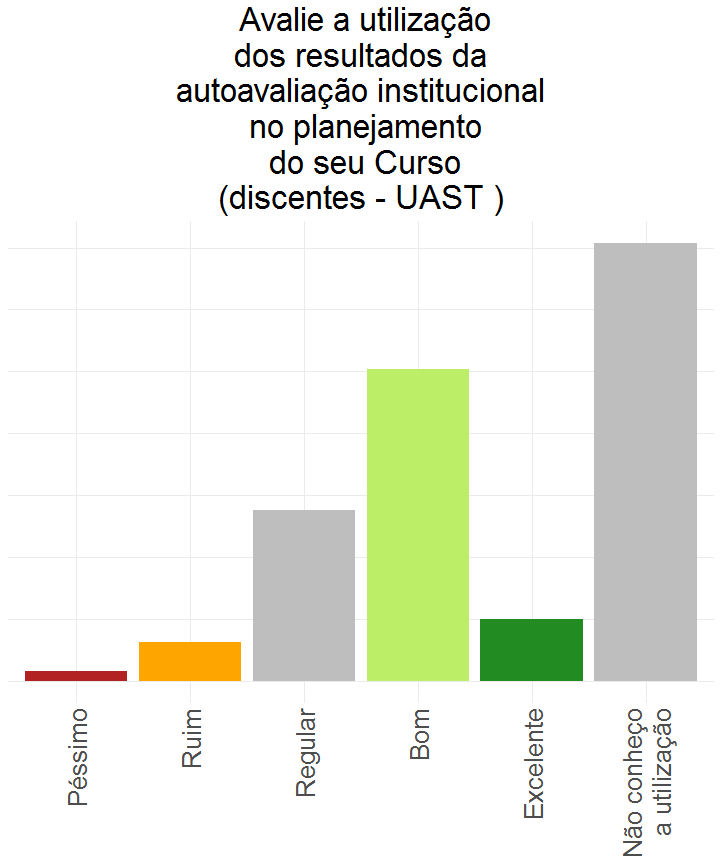

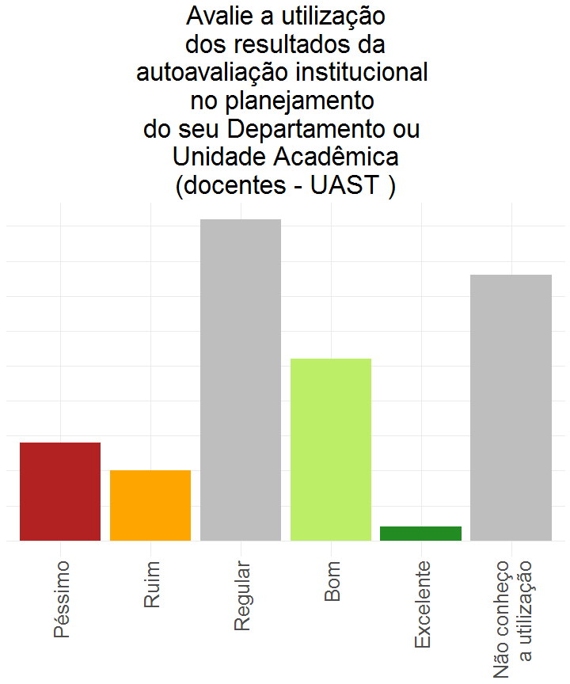

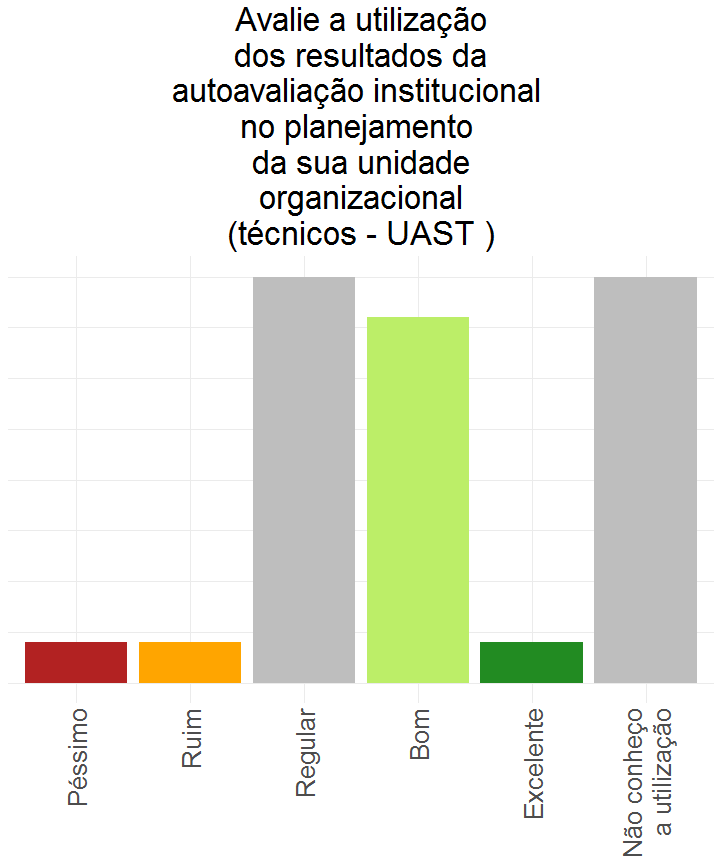

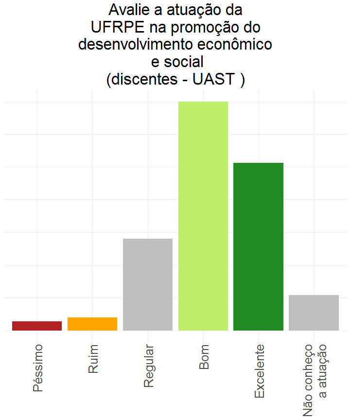

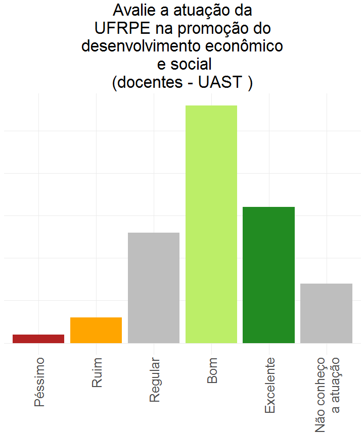

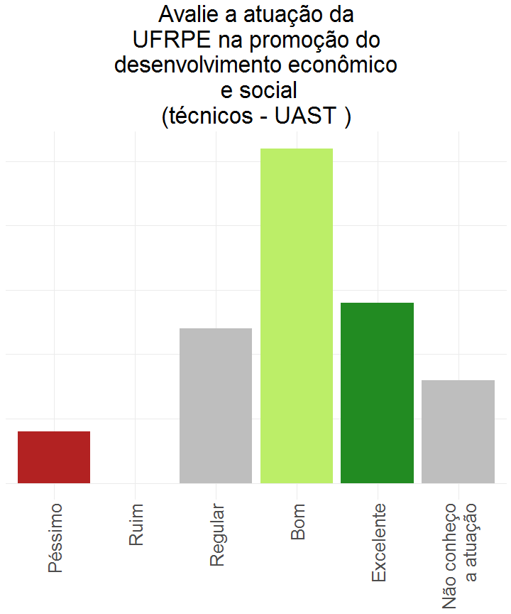

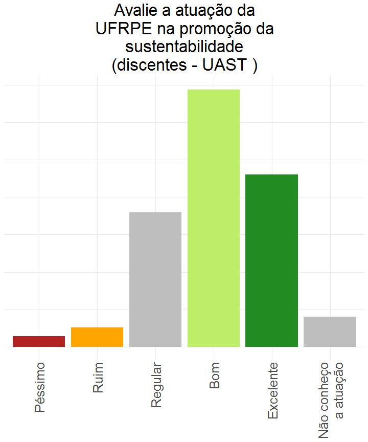

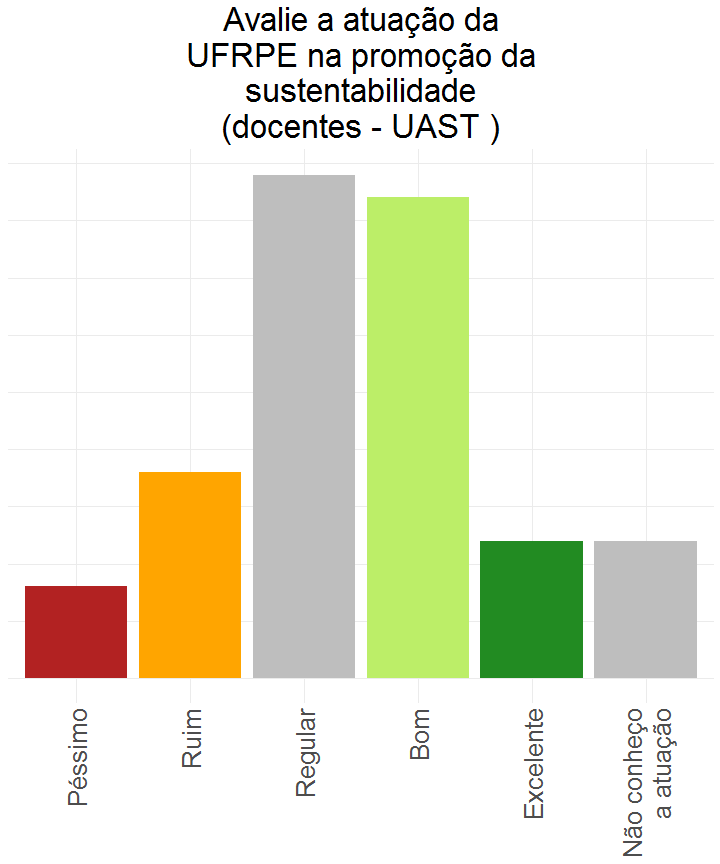

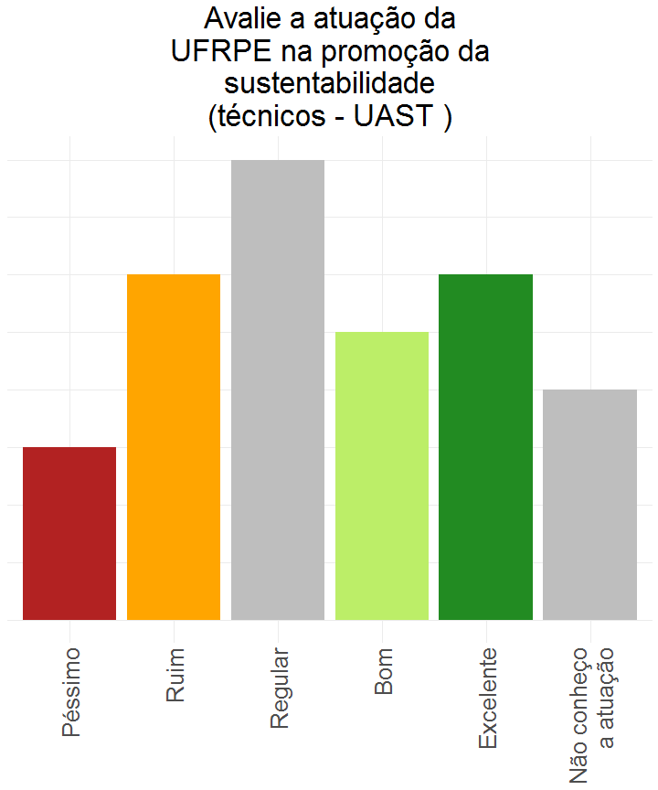

[6 more figures not shown]

# 3 DESTAQUES - PLANEJAMENTO E AVALIAÇÃO INSTITUCIONAL

Esta seção apresenta os resultados com maiores e menores médias numéricas referentes à avaliação do Planejamento e da Avaliação Institucional da UFRPE, conforme respondido pelos integrantes da Unidade Acadêmica de Serra Talhada (UAST).

A seguir são apresentados os resultados classificados por segmento: discentes, docentes e técnicos.

## 3.1 Discentes (UAST)

Durante o período de avaliação esta unidade contava com 1782 **discentes** aptos a participar da avaliação, dos quais 417 (23.4%) responderam ao questionário. Do total das respostas referentes a Planejamento e Avaliação da instituição, 0.68% foram “péssimo”, 3.2% foram “ruim”, 19.22% foram “regular”, 37.49% foram “bom”, 18.03% foram “excelente”, e 21.38% foram outras opções de resposta.

### 3.1.1 Maiores médias:

Lista das 3 perguntas com respostas mais positivas, de um total de 6 perguntas, com base na média ponderada das respostas dos discentes desta unidade acadêmica.

| Item | Média |
| --- | --- |
| Avalie o acesso a este questionário de autoavaliação da UFRPE | 8.1 |
| Avalie o Projeto de Autoavaliação Institucional adotado pela Comissão Própria de Avaliação (CPA) | 7.2 |
| Avalie o acesso aos relatórios de autoavaliação da UFRPE | 7.2 |

### 3.1.2 Menores médias:

Lista das 3 perguntas com respostas mais negativas, de um total de 6 perguntas, com base na média ponderada das respostas dos discentes desta unidade.

| Item | Média |
| --- | --- |
| Avalie a utilização dos resultados da autoavaliação institucional no planejamento do seu Curso | 6.6 |
| Avalie a visibilidade da Comissão Própria de Avaliação (CPA) nas Mídias Sociais (Facebook e Instagram) | 6.8 |
| Avalie as ações de planejamento no seu curso | 6.8 |

## 3.2 Docentes (UAST)

Durante o período de avaliação esta unidade contava com 222 **docentes** aptos a participar da avaliação, dos quais 68 (30.63%) responderam ao questionário. Do total das respostas referentes a Planejamento e Avaliação da instituição, 3.43% foram “péssimo”, 7.84% foram “ruim”, 23.77% foram “regular”, 33.09% foram “bom”, 11.03% foram “excelente”, e 20.83% foram outras opções de resposta.

### 3.2.1 Maiores médias:

Lista das 3 perguntas com respostas mais positivas, de um total de 6 perguntas, com base na média ponderada das respostas dos docentes desta unidade acadêmica.

| Item | Média |
| --- | --- |
| Avalie o acesso a este questionário de autoavaliação da UFRPE. | 7.9 |
| Avalie o acesso aos relatórios de autoavaliação da UFRPE | 7.2 |
| Avalie o Projeto de Autoavaliação Institucional adotado pela Comissão Própria de Avaliação (CPA) | 6.7 |

### 3.2.2 Menores médias:

Lista das 3 perguntas com respostas mais negativas, de um total de 6 perguntas, com base na média ponderada das respostas dos docentes desta unidade acadêmica.

| Item | Média |
| --- | --- |
| Avalie a utilização dos resultados da autoavaliação institucional no planejamento do seu Departamento ou Unidade Acadêmica | 4.8 |
| Avalie a visibilidade da Comissão Própria de Avaliação (CPA) nas Mídias Sociais (Facebook e Instagram) | 5.1 |
| Avalie as ações de planejamento no seu Departamento ou Unidade Acadêmica | 5.1 |

## 3.3 Técnicos (UAST)

Durante o período de avaliação esta unidade contava com 78 **técnicos** aptos a participar da avaliação, dos quais 32 (41.03%) responderam ao questionário. Do total das respostas referentes a Planejamento e Avaliação da instituição, 1.56% foram “péssimo”, 4.17% foram “ruim”, 26.04% foram “regular”, 38.54% foram “bom”, 10.42% foram “excelente”, e 19.27% foram outras opções de resposta.

### 3.3.1 Maiores médias:

Lista das 3 perguntas com respostas mais positivas, de um total de 6 perguntas, com base na média ponderada das respostas dos técnicos desta unidade acadêmica.

| Item | Média |
| --- | --- |
| Avalie o acesso a este questionário de autoavaliação da UFRPE no site da Comissão Própria de Avaliaação (CPA) | 7.7 |
| Avalie o acesso aos relatórios de autoavaliação da UFRPE | 7.2 |
| Avalie o Projeto de Autoavaliação Institucional adotado pela Comissão Própria de Avaliação (CPA) | 7.0 |

### 3.3.2 Menores médias:

Lista das 3 perguntas com respostas mais negativas, de um total de 6 perguntas, com base na média ponderada das respostas dos técnicos desta unidade acadêmica.

| Item | Média |
| --- | --- |
| Avalie as ações de planejamento na sua unidade organizacional | 5.7 |
| Avalie a visibilidade da Comissão Própria de Avaliação (CPA) nas Mídias Sociais (Facebook e Instagram) | 5.8 |
| Avalie a utilização dos resultados da autoavaliação institucional no planejamento de sua unidade organizacional | 5.9 |

# 4 DESTAQUES - DESENVOLVIMENTO INSTITUCIONAL

Esta seção apresenta os resultados com maiores e menores médias numéricas referentes à avaliação do Desenvolvimento Institucional da UFRPE, conforme respondido pelos integrantes da Unidade Acadêmica de Serra Talhada (UAST).

A seguir são apresentados os resultados classificados por segmento: discentes, docentes e técnicos.

## 4.1 Discentes (UAST)

Durante o período de avaliação esta unidade contava com 1782 **discentes** aptos a participar da avaliação, dos quais 417 (23.4%) responderam ao questionário. Do total das respostas referentes ao desenvolvimento institucional, 1.11% foram “péssimo”, 3.47% foram “ruim”, 18.88% foram “regular”, 36.43% foram “bom”, 21.3% foram “excelente”, e 18.81% foram outras opções de resposta.

### 4.1.1 Maiores médias:

Lista das 3 perguntas com respostas mais positivas, de um total de 11 perguntas, com base na média ponderada das respostas dos discentes desta unidade acadêmica.

| Item | Média |
| --- | --- |
| Avalie a atuação da UFRPE na promoção da igualdade étnico-racial | 8.1 |
| Avalie a atuação da UFRPE na valorização da diversidade | 8.0 |
| Avalie a atuação da UFRPE na promoção dos Direitos Humanos | 7.8 |

### 4.1.2 Menores médias:

Lista das 3 perguntas com respostas mais negativas, de um total de 11 perguntas, com base na média ponderada das respostas dos discentes desta unidade acadêmica.

| Item | Média |
| --- | --- |
| Avalie a atuação da UFRPE na promoção da produção artística | 6.3 |
| Avalie o seu conhecimento sobre o Plano de Desenvolvimento Institucional | 6.3 |
| Avalie seu conhecimento sobre o Plano de Gestão de Logística Sustentável (PLS) da UFRPE | 6.7 |

## 4.2 Docentes (UAST)

Durante o período de avaliação esta unidade contava com 222 **docentes** aptos a participar da avaliação, dos quais 68 (30.63%) responderam ao questionário. Do total das respostas referentes ao desenvolvimento institucional, 2.94% foram “péssimo”, 7.49% foram “ruim”, 22.19% foram “regular”, 34.63% foram “bom”, 11.1% foram “excelente”, e 21.66% foram outras opções de resposta.

### 4.2.1 Maiores médias:

Lista das 3 perguntas com respostas mais positivas, de um total de 11 perguntas, com base na média ponderada das respostas dos docentes desta unidade acadêmica.

| Item | Média |
| --- | --- |
| Avalie a atuação da UFRPE na valorização da diversidade | 7.5 |
| Avalie a atuação da UFRPE na promoção da igualdade étnico-racial | 7.3 |
| Avalie a atuação da UFRPE na promoção do desenvolvimento econômico e social | 7.3 |

### 4.2.2 Menores médias:

Lista das 3 perguntas com respostas mais negativas, de um total de 11 perguntas, com base na média ponderada das respostas dos docentes desta unidade acadêmica.

| Item | Média |
| --- | --- |
| Avalie a atuação da UFRPE na promoção da produção artística | 5.0 |
| Avalie seu conhecimento sobre o Plano de Gestão de Logística Sustentável (PLS) da UFRPE | 5.2 |
| Avalie a atuação da UFRPE na promoção da sustentabilidade | 5.6 |

## 4.3 Técnicos (UAST)

Durante o período de avaliação esta unidade contava com 78 **técnicos** aptos a participar da avaliação, dos quais 32 (41.03%) responderam ao questionário. Do total das respostas referentes ao desenvolvimento institucional, 2.56% foram “péssimo”, 5.4% foram “ruim”, 22.16% foram “regular”, 31.82% foram “bom”, 12.78% foram “excelente”, e 25.28% foram outras opções de resposta.

### 4.3.1 Maiores médias:

Lista das 3 perguntas com respostas mais positivas, de um total de 11 perguntas, com base na média ponderada das respostas dos técnicos desta unidade acadêmica.

| Item | Média |
| --- | --- |
| Avalie a atuação da UFRPE na promoção da igualdade étnico-racial | 7.6 |
| Avalie a atuação da UFRPE na promoção dos Direitos Humanos | 7.5 |
| Avalie a atuação da UFRPE na valorização da diversidade | 7.4 |

### 4.3.2 Menores médias:

Lista das 3 perguntas com respostas mais negativas, de um total de 11 perguntas, com base na média ponderada das respostas dos técnicos desta unidade acadêmica.

| Item | Média |
| --- | --- |
| Avalie a atuação da UFRPE na promoção da sustentabilidade | 5.4 |
| Avalie o seu conhecimento sobre o Plano de Desenvolvimento Institucional (PDI) | 5.7 |
| Avalie o alinhamento das diretrizes e objetivos estratégicos do Plano de Desenvolvimento Institucional (PDI) com as ações executadas na UFRPE | 5.8 |

# 5 RESULTADOS COMPLETOS

Esta seção apresenta as tabelas com as respostas a todas as perguntas do questionário de avaliação UFRPE 2019, conforme respondido pelos integrantes desta unidade, classificadas por segmento.

## 5.1 Planejamento e Avaliação Institucional

### 5.1.1 Discentes (UAST)

Resultados da avaliação de **Planejamento e Avaliação Institucional** da UFRPE, conforme respondido pelos discentes desta unidade acadêmica.

| Média | Item | Péssimo (0) | Ruim (2.5) | Regular (5) | Bom (7.5) | Excelente (10) | OOR* |
| --- | --- | --- | --- | --- | --- | --- | --- |
| 8.1 | Avalie o acesso a este questionário de autoavaliação da UFRPE | 1 | 8 | 53 | 186 | 169 | 0 |
| 7.2 | Avalie o Projeto de Autoavaliação Institucional adotado pela Comissão Própria de Avaliação (CPA) | 1 | 6 | 76 | 173 | 58 | 103 |
| 7.2 | Avalie o acesso aos relatórios de autoavaliação da UFRPE | 2 | 12 | 99 | 169 | 87 | 48 |
| 6.8 | Avalie a visibilidade da Comissão Própria de Avaliação (CPA) nas Mídias Sociais (Facebook e Instagram) | 2 | 18 | 72 | 114 | 46 | 165 |
| 6.8 | Avalie as ações de planejamento no seu curso | 7 | 20 | 112 | 170 | 66 | 42 |
| 6.6 | Avalie a utilização dos resultados da autoavaliação institucional no planejamento do seu Curso | 4 | 16 | 69 | 126 | 25 | 177 |

*OOR: Outras opções de resposta

### 5.1.2 Docentes (UAST)

Resultados da avaliação de Planejamento e Avaliação Institucional da UFRPE, conforme respondido pelos docentes desta unidade acadêmica.

| Média | Item | Péssimo (0) | Ruim (2.5) | Regular (5) | Bom (7.5) | Excelente (10) | OOR* |
| --- | --- | --- | --- | --- | --- | --- | --- |
| 7.9 | Avalie o acesso a este questionário de autoavaliação da UFRPE. | 0 | 1 | 10 | 35 | 22 | 0 |
| 7.2 | Avalie o acesso aos relatórios de autoavaliação da UFRPE | 1 | 0 | 16 | 32 | 12 | 7 |
| 6.7 | Avalie o Projeto de Autoavaliação Institucional adotado pela Comissão Própria de Avaliação (CPA) | 1 | 2 | 12 | 26 | 5 | 22 |
| 5.1 | Avalie a visibilidade da Comissão Própria de Avaliação (CPA) nas Mídias Sociais (Facebook e Instagram) | 1 | 13 | 14 | 9 | 4 | 27 |
| 5.1 | Avalie as ações de planejamento no seu Departamento ou Unidade Acadêmica | 4 | 11 | 22 | 20 | 1 | 10 |
| 4.8 | Avalie a utilização dos resultados da autoavaliação institucional no planejamento do seu Departamento ou Unidade Acadêmica | 7 | 5 | 23 | 13 | 1 | 19 |

*OOR: Outras opções de resposta

### 5.1.3 Técnicos (UAST)

Resultados da avaliação de Planejamento e Avaliação Institucional da UFRPE, conforme respondido pelos técnicos desta unidade acadêmica.

| Média | Item | Péssimo (0) | Ruim (2.5) | Regular (5) | Bom (7.5) | Excelente (10) | OOR* |
| --- | --- | --- | --- | --- | --- | --- | --- |
| 7.7 | Avalie o acesso a este questionário de autoavaliação da UFRPE no site da Comissão Própria de Avaliaação (CPA) | 0 | 0 | 7 | 16 | 9 | 0 |
| 7.2 | Avalie o acesso aos relatórios de autoavaliação da UFRPE | 0 | 1 | 7 | 16 | 5 | 3 |
| 7.0 | Avalie o Projeto de Autoavaliação Institucional adotado pela Comissão Própria de Avaliação (CPA) | 0 | 0 | 7 | 14 | 2 | 9 |
| 5.9 | Avalie a utilização dos resultados da autoavaliação institucional no planejamento de sua unidade organizacional | 1 | 1 | 10 | 9 | 1 | 10 |
| 5.8 | Avalie a visibilidade da Comissão Própria de Avaliação (CPA) nas Mídias Sociais (Facebook e Instagram) | 1 | 3 | 8 | 8 | 2 | 10 |
| 5.7 | Avalie as ações de planejamento na sua unidade organizacional | 1 | 3 | 11 | 11 | 1 | 5 |

*OOR: Outras opções de resposta

## 5.2 Desenvolvimento Institucional

### 5.2.1 Discentes (UAST)

Resultados da avaliação do **Desenvolvimento Institucional** da UFRPE, conforme respondido pelos discentes desta unidade acadêmica.

| Média | Item | Péssimo (0) | Ruim (2.5) | Regular (5) | Bom (7.5) | Excelente (10) | OOR* |
| --- | --- | --- | --- | --- | --- | --- | --- |
| 8.1 | Avalie a atuação da UFRPE na promoção da igualdade étnico-racial | 1 | 3 | 57 | 174 | 160 | 22 |
| 8.0 | Avalie a atuação da UFRPE na valorização da diversidade | 5 | 6 | 53 | 180 | 152 | 21 |
| 7.8 | Avalie a atuação da UFRPE na promoção dos Direitos Humanos | 4 | 5 | 72 | 176 | 136 | 24 |
| 7.6 | Avalie a atuação da UFRPE na promoção do desenvolvimento econômico e social | 7 | 10 | 70 | 175 | 128 | 27 |
| 7.4 | Avalie a atuação da UFRPE na promoção da sustentabilidade | 7 | 13 | 90 | 172 | 115 | 20 |
| 7.1 | Avalie a atuação da UFRPE na gestão do patrimônio cultural | 5 | 18 | 94 | 173 | 86 | 41 |
| 7.0 | Avalie o Plano de Desenvolvimento Institucional (PDI) da UFRPE como instrumento de gestão (Planejamento, execução e avaliação) | 3 | 5 | 75 | 136 | 40 | 158 |
| 6.8 | Avalie o alinhamento das diretrizes e objetivos estratégicos do Plano de Desenvolvimento Institucional (PDI) com as ações executadas na UFRPE | 1 | 9 | 80 | 132 | 32 | 163 |
| 6.7 | Avalie seu conhecimento sobre o Plano de Gestão de Logística Sustentável (PLS) da UFRPE | 4 | 17 | 62 | 97 | 39 | 198 |
| 6.3 | Avalie a atuação da UFRPE na promoção da produção artística | 10 | 42 | 124 | 136 | 59 | 46 |
| 6.3 | Avalie o seu conhecimento sobre o Plano de Desenvolvimento Institucional | 4 | 31 | 89 | 120 | 30 | 143 |

*OOR: Outras opções de resposta

### 5.2.2 Docentes (UAST)

Resultados da avaliação do Desenvolvimento Institucional da UFRPE, conforme respondido pelos docentes desta unidade acadêmica.

| Média | Item | Péssimo (0) | Ruim (2.5) | Regular (5) | Bom (7.5) | Excelente (10) | OOR* |
| --- | --- | --- | --- | --- | --- | --- | --- |
| 7.5 | Avalie a atuação da UFRPE na valorização da diversidade | 0 | 3 | 12 | 30 | 18 | 5 |
| 7.3 | Avalie a atuação da UFRPE na promoção da igualdade étnico-racial | 0 | 3 | 14 | 26 | 16 | 9 |
| 7.3 | Avalie a atuação da UFRPE na promoção do desenvolvimento econômico e social | 1 | 3 | 13 | 28 | 16 | 7 |
| 7.1 | Avalie a atuação da UFRPE na promoção dos Direitos Humanos | 0 | 3 | 16 | 27 | 13 | 9 |
| 6.5 | Avalie o PDI da UFRPE como instrumento de gestão ( Planejamento, execução e avaliação) | 2 | 4 | 10 | 31 | 3 | 18 |
| 6.0 | Avalie a atuação da UFRPE na gestão de patrimônio cultural | 3 | 6 | 14 | 22 | 5 | 18 |
| 6.0 | Avalie o alinhamento das diretrizes e objetivos estratégicos do PDI com as as ações executadas na UFRPE | 2 | 3 | 17 | 22 | 2 | 22 |
| 5.7 | Avalie o seu conhecimento sobre o Plano de Desenvolvimento Institucional (PDI) | 2 | 9 | 16 | 25 | 1 | 15 |
| 5.6 | Avalie a atuação da UFRPE na promoção da sustentabilidade | 4 | 9 | 22 | 21 | 6 | 6 |
| 5.2 | Avalie seu conhecimento sobre o Plano de Gestão de Logística Sustentável (PLS) da UFRPE | 2 | 5 | 14 | 8 | 2 | 37 |
| 5.0 | Avalie a atuação da UFRPE na promoção da produção artística | 6 | 8 | 18 | 19 | 1 | 16 |

*OOR: Outras opções de resposta

### 5.2.3 Técnicos (UAST)

Resultados da avaliação do Desenvolvimento Institucional da UFRPE, conforme respondido pelos técnicos desta unidade acadêmica.

| Média | Item | Péssimo (0) | Ruim (2.5) | Regular (5) | Bom (7.5) | Excelente (10) | OOR* |
| --- | --- | --- | --- | --- | --- | --- | --- |
| 7.6 | Avalie a atuação da UFRPE na promoção da igualdade étnico-racial | 0 | 1 | 3 | 16 | 6 | 6 |
| 7.5 | Avalie a atuação da UFRPE na promoção dos Direitos Humanos | 0 | 0 | 7 | 14 | 7 | 4 |
| 7.4 | Avalie a atuação da UFRPE na valorização da diversidade | 0 | 0 | 5 | 18 | 4 | 5 |
| 7.1 | Avalie a atuação da UFRPE na promoção do desenvolvimento econômico e social | 2 | 0 | 6 | 13 | 7 | 4 |
| 6.7 | Avalie o Plano de Desenvolvimento Institucional (PDI) da UFRPE como instrumento de gestão ( Planejamento, execução e avaliação) | 0 | 1 | 8 | 9 | 3 | 11 |
| 6.5 | Avalie a atuação da UFRPE na gestão do patrimônio cultural | 1 | 2 | 6 | 9 | 4 | 10 |
| 6.2 | Avalie seu conhecimento sobre o Plano de Gestão de Logística Sustentável (PLS) da UFRPE | 1 | 0 | 9 | 4 | 3 | 15 |
| 5.9 | Avalie a atuação da UFRPE na promoção da produção artística | 2 | 2 | 9 | 7 | 4 | 8 |
| 5.8 | Avalie o alinhamento das diretrizes e objetivos estratégicos do Plano de Desenvolvimento Institucional (PDI) com as ações executadas na UFRPE | 0 | 3 | 9 | 7 | 1 | 12 |
| 5.7 | Avalie o seu conhecimento sobre o Plano de Desenvolvimento Institucional (PDI) | 0 | 4 | 8 | 10 | 0 | 10 |
| 5.4 | Avalie a atuação da UFRPE na promoção da sustentabilidade | 3 | 6 | 8 | 5 | 6 | 4 |

*OOR: Outras opções de resposta